## Datos limpios

Una vez que importamos datos a R es conveniente limpiarlos, esto implica almacenarlos de una manera consisistente que nos permita enfocarnos en responder preguntas de los datos en lugar de estar luchando con los datos.

Datos limpios son datos que facilitan las tareas del análisis de datos:

- **Visualización**: Resúmenes de datos usando gráficas, análisis exploratorio, o presentación de resultados.
- **Manipulación**: Manipulación de variables como agregar, filtrar, reordenar, transformar.
- **Modelación**: Ajustar modelos es sencillo si los datos están en la forma correcta.

Los **principios de los datos limpios** [@tidy] proveen una manera estándar de organizar la información:

1. Cada columna es una variable.
2. Cada renglón es una observación .
3. Cada celda es un único valor.

Vale la pena notar que los principios de los datos limpios se pueden ver como teoría de algebra relacional para estadísticos, estós principios junto con *cada tipo de unidad observacional forma una tabla* equivalen a [la tercera forma normal de Codd](https://en.wikipedia.org/wiki/Third_normal_form) con enfoque en una sola tabla de datos en lugar de muchas conectadas en bases de datos relacionales.

Veamos un ejemplo:

La mayor parte de las bases de datos en estadística tienen forma rectangular, ¿cuántas variables tiene la siguiente tabla?

|  | tratamientoA | tratamientoB |
| --- | --- | --- |
| Juan Aguirre | - | 2 |
| Ana Bernal | 16 | 11 |
| José López | 3 | 1 |

La tabla anterior también se puede estructurar de la siguiente manera:

|  | Juan Aguirre | Ana Bernal | José López |
| --- | --- | --- | --- |
| tratamientoA | - | 16 | 3 |
| tratamientoB | 2 | 11 | 1 |

Si vemos los principios (cada variable forma una columna, cada observación forma un renglón, cada tipo de unidad observacional forma una tabla), ¿las tablas anteriores cumplen los principios?

Para responder la pregunta identifiquemos primero cuáles son las variables y cuáles las observaciones de esta pequeña base. Las variables son: persona/nombre, tratamiento y resultado. Entonces, siguiendo los principios de *datos limpios* obtenemos la siguiente estructura:

| nombre | tratamiento | resultado |
| --- | --- | --- |
| Juan Aguirre | a | - |
| Ana Bernal | a | 16 |
| José López | a | 3 |
| Juan Aguirre | b | 2 |
| Ana Bernal | b | 11 |
| José López | b | 1 |

### Limpieza bases de datos

Los principios de los datos limpios parecen obvios pero la mayor parte de los datos no los cumplen debido a:

1. La mayor parte de la gente no está familiarizada con los principios y es difícil derivarlos por uno mismo.
2. Los datos suelen estar organizados para facilitar otros aspectos que no son análisis, por ejemplo, la captura.

Algunos de los problemas más comunes en las bases de datos que no están *limpias* son:

- Los encabezados de las columnas son valores y no nombres de variables.
- Más de una variable por columna.
- Las variables están organizadas tanto en filas como en columnas.
- Más de un tipo de observación en una tabla.
- Una misma unidad observacional está almacenada en múltiples tablas.

La mayor parte de estos problemas se pueden arreglar con pocas herramientas, a continuación veremos como *limpiar* datos usando 2 funciones del paquete `tidyr`:

- **gather**: recibe múltiples columnas y las junta en pares de valores y nombres y alarga los datos.
- **spread**: recibe 2 columnas y las separa, haciendo los datos más anchos.

Repasaremos los problemas más comunes que se encuentran en conjuntos de datos sucios y mostraremos como se puede manipular la tabla de datos (usando las funciones *gather* y *spread*) con el fin de estructurarla para que cumpla los principios de datos limpios.

### Los encabezados de las columanas son valores

Usaremos ejemplos para entender los conceptos más facilmente. Comenzaremos con una tabla de datos que contiene las mediciones de partículas suspendidas PM2.5 de la red automática de monitoreo atmosférico ([RAMA](http://www.aire.cdmx.gob.mx)) para los primeros meses del 2019.

```r
library(tidyverse)
library(estcomp)
pm25_2019
```

```
#> # A tibble: 5,088 x 26
#>    date        hour   AJM   AJU   BJU   CAM   CCA COY   FAR     GAM   HGM
#>    <date>     <dbl> <dbl> <dbl> <dbl> <dbl> <dbl> <lgl> <lgl> <dbl> <dbl>
#>  1 2019-01-01     1    19    35    62    90    66 NA    NA       NA    56
#>  2 2019-01-01     2    17    24    88   104    84 NA    NA       NA    61
#>  3 2019-01-01     3    14    20   107   140    95 NA    NA       NA    74
#>  4 2019-01-01     4     6    15   101   162    97 NA    NA       NA    90
#>  5 2019-01-01     5     4     8   121   133    88 NA    NA       NA    90
#>  6 2019-01-01     6     7     7    93   106    77 NA    NA       NA   106
#>  7 2019-01-01     7    12     8    84    98    51 NA    NA       NA   115
#>  8 2019-01-01     8    15     7   101    82    39 NA    NA       NA    90
#>  9 2019-01-01     9    24     3    89    54    26 NA    NA       NA    90
#> 10 2019-01-01    10    24    NA    88    76    26 NA    NA       NA    99
#> # … with 5,078 more rows, and 15 more variables: INN <dbl>, MER <dbl>,
#> #   MGH <dbl>, MON <dbl>, MPA <lgl>, NEZ <dbl>, PED <dbl>, SAC <lgl>,
#> #   SAG <dbl>, SFE <dbl>, SJA <lgl>, TLA <dbl>, UAX <dbl>, UIZ <dbl>,
#> #   XAL <dbl>
```

¿Cuáles son las variables en estos datos?

Esta base de datos tiene 4 variables: fecha, hora, estación y medición (en microgramos por metro cúbico $\mu g/m^3$).

Al alargar los datos desaparecerán las columnas que se agrupan y darán lugar a dos nuevas columnas: la correspondiente a estación y la correspondiente a medición. Entonces, usamos la función `gather()` que recibe los argumentos:

- data: base de datos que vamos a reestructurar.
- key: nombre de la nueva variable que contiene lo que fueron los nombres de columnas que apilamos.
- value: nombre de la variable que almacenará los valores que corresponden a cada *key*.
- …: lo último que especificamos son las columnas que vamos a apilar, la notación para seleccionarlas es la misma que usamos con `select()`.

```r
pm25_2019_tidy <- gather(pm25_2019, key = station, value = measurement, -date,
  -hour)
head(pm25_2019_tidy)
```

```
#> # A tibble: 6 x 4
#>   date        hour station measurement
#>   <date>     <dbl> <chr>         <dbl>
#> 1 2019-01-01     1 AJM              19
#> 2 2019-01-01     2 AJM              17
#> 3 2019-01-01     3 AJM              14
#> 4 2019-01-01     4 AJM               6
#> 5 2019-01-01     5 AJM               4
#> 6 2019-01-01     6 AJM               7
```

```r
tail(pm25_2019_tidy)
```

```
#> # A tibble: 6 x 4
#>   date        hour station measurement
#>   <date>     <dbl> <chr>         <dbl>
#> 1 2019-07-31    19 XAL              12
#> 2 2019-07-31    20 XAL              11
#> 3 2019-07-31    21 XAL               7
#> 4 2019-07-31    22 XAL              NA
#> 5 2019-07-31    23 XAL               7
#> 6 2019-07-31    24 XAL               7
```

Observemos que en la tabla original teníamos bajo la columna *AJM*, en el renglón correspondiente a *2019-01-01* hora *1* un valor de 19, y podemos ver que este valor en la tabla larga se almacena bajo la columna *measurement* y corresponde a la estación *AJM*.

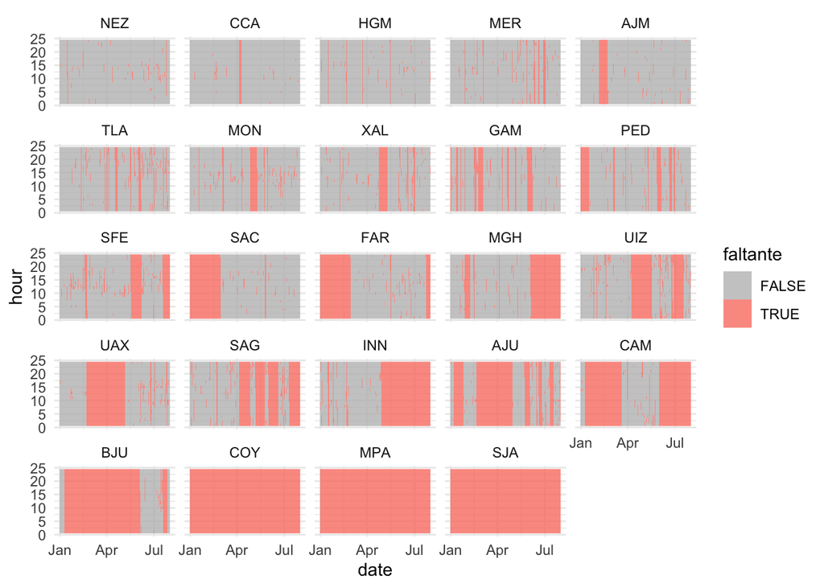

```r
pm25_2019_tidy %>%
    mutate(
        missing = is.na(measurement),
        station = reorder(station, missing, sum)
        ) %>%
    ggplot(aes(x = date, y = hour, fill = is.na(measurement))) +
    geom_raster(alpha = 0.8) +
    facet_wrap(~ station) +
    scale_fill_manual("faltante",
        values = c("TRUE" = "salmon", "FALSE" = "gray"))
```

Otro ejemplo, veamos los datos `df_edu`, ¿cuántas variables tenemos?

```r
df_edu
```

```
#> # A tibble: 7,371 x 16
#>    state_code municipio_code region state_name state_abbr municipio_name
#>    <chr>      <chr>          <chr>  <chr>      <chr>      <chr>
#>  1 01         001            01001  Aguascali… AGS        Aguascalientes
#>  2 01         001            01001  Aguascali… AGS        Aguascalientes
#>  3 01         001            01001  Aguascali… AGS        Aguascalientes
#>  4 01         002            01002  Aguascali… AGS        Asientos
#>  5 01         002            01002  Aguascali… AGS        Asientos
#>  6 01         002            01002  Aguascali… AGS        Asientos
#>  7 01         003            01003  Aguascali… AGS        Calvillo
#>  8 01         003            01003  Aguascali… AGS        Calvillo
#>  9 01         003            01003  Aguascali… AGS        Calvillo
#> 10 01         004            01004  Aguascali… AGS        Cosío
#> # … with 7,361 more rows, and 10 more variables: sex <chr>, pop_15 <dbl>,
#> #   no_school <dbl>, preschool <dbl>, elementary <dbl>, secondary <dbl>,
#> #   highschool <dbl>, higher_edu <dbl>, other <dbl>, schoolyrs <dbl>
```

Notemos que el nivel de escolaridad esta guardado en 6 columnas (preschool, elementary, …, other), este tipo de almacenamiento *no es limpio* aunque puede ser útil al momento de ingresar la información o para presentarla.

Para tener datos *limpios* apilamos los niveles de escolaridad de manera que sea una sola columna (nuevamente alargamos los datos):

```r
df_edu_tidy <- gather(data = df_edu, grade, percent, preschool:other,
  na.rm = TRUE)
glimpse(df_edu_tidy)
```

```
#> Observations: 44,226
#> Variables: 12
#> $ state_code     <chr> "01", "01", "01", "01", "01", "01", "01", "01", "…
#> $ municipio_code <chr> "001", "001", "001", "002", "002", "002", "003", …
#> $ region         <chr> "01001", "01001", "01001", "01002", "01002", "010…
#> $ state_name     <chr> "Aguascalientes", "Aguascalientes", "Aguascalient…
#> $ state_abbr     <chr> "AGS", "AGS", "AGS", "AGS", "AGS", "AGS", "AGS", …
#> $ municipio_name <chr> "Aguascalientes", "Aguascalientes", "Aguascalient…
#> $ sex            <chr> "Total", "Hombres", "Mujeres", "Total", "Hombres"…
#> $ pop_15         <dbl> 631064, 301714, 329350, 31013, 14991, 16022, 3867…
#> $ no_school      <dbl> 2.662329, 2.355211, 2.943677, 4.011221, 4.389300,…
#> $ schoolyrs      <dbl> 10.211152, 10.380144, 10.056383, 7.854005, 7.6920…
#> $ grade          <chr> "preschool", "preschool", "preschool", "preschool…
#> $ percent        <dbl> 0.17335801, 0.17466873, 0.17215728, 0.25795634, 0…
```

El parámetro `na.rm = TRUE` se utiliza para eliminar los renglones con valores faltantes en la columna de porcentaje, esto es, eliminamos aquellas observaciones que tenían `NA` en la columnas de nivel de escolaridad de la tabla ancha. En este caso optamos por que los faltantes sean implícitos, la conveniencia de tenerlos implícitos/explícitos dependerá de la aplicación.

Con los datos limpios es facil hacer manipulaciones y grfiacs, ¿cómo habrían hecho la siguiente gráfica antes de la limpieza?

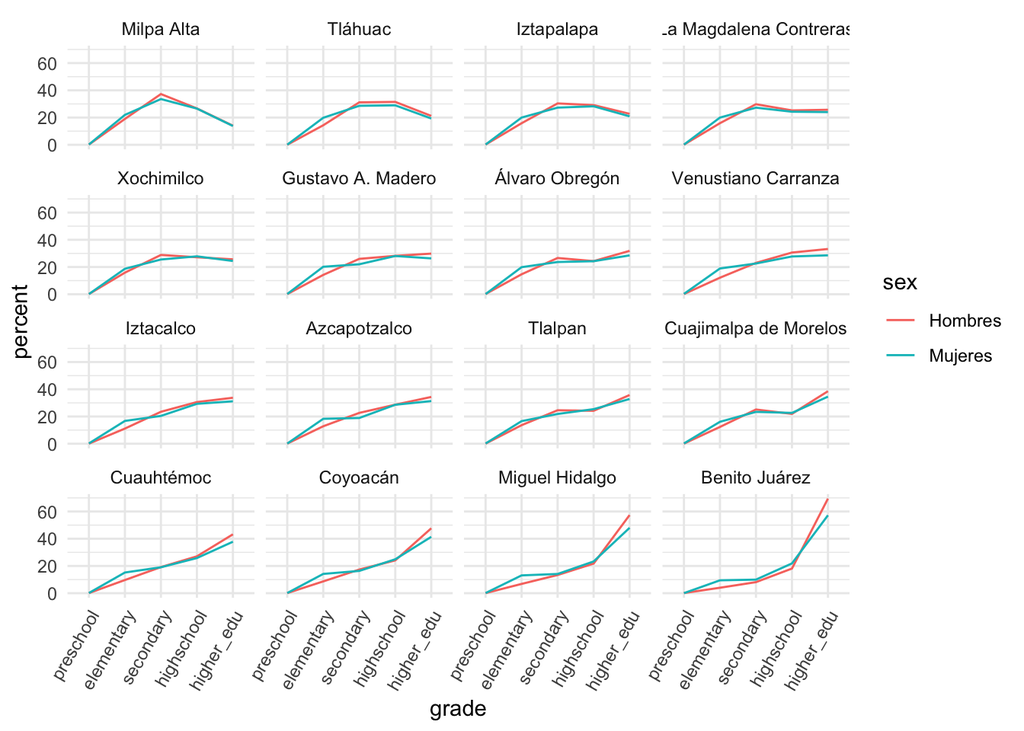

```r
df_edu_cdmx <- df_edu_tidy %>%
    filter(state_abbr == "CDMX", sex != "Total", grade != "other") %>%
    mutate(municipio_name = reorder(municipio_name, percent, last))

ggplot(df_edu_cdmx, aes(x = grade,
    y = percent, group = sex, color = sex)) +
    geom_path() +
    facet_wrap(~municipio_name) +
    theme(axis.text.x = element_text(angle = 60, hjust = 1)) +
    scale_x_discrete(limits = c("preschool", "elementary",
        "secondary", "highschool", "higher_edu"))
```

### Una columna asociada a más de una variable

Utilizaremos un subconjunto de los datos de la prueba ENLACE a nivel primaria, la prueba [ENLACE](http://www.enlace.sep.gob.mx/ba/) evaluaba a todos los alumnos de tercero a sexto de primaria y a los alumnos de secundaria del país en 3 áreas: *español*, *matemáticas* y *formación cívica y ética*.

```r
data("enlacep_2013")
enlacep_sub_2013 <- enlacep_2013 %>%
    select(CVE_ENT:PUNT_FCE_6) %>%
    sample_n(1000)
glimpse(enlacep_sub_2013)
```

```
#> Observations: 1,000
#> Variables: 22
#> $ CVE_ENT    <chr> "11", "15", "24", "25", "15", "06", "13", "10", "21",…
#> $ NOM_ENT    <chr> "GUANAJUATO", "MEXICO", "SAN LUIS POTOSI", "SINALOA",…
#> $ CCT        <chr> "11DPR3703N", "15DPR1974O", "24DPR0999Y", "25DPR1173D…
#> $ TURNO      <chr> "VESPERTINO", "MATUTINO", "MATUTINO", "MATUTINO", "MA…
#> $ ESCUELA    <chr> "20 DE NOVIEMBRE", "GUADALUPE VICTORIA", "JOSE MA. MO…
#> $ TIPO       <chr> "GENERAL", "GENERAL", "GENERAL", "GENERAL", "GENERAL"…
#> $ CVE_MUN    <chr> "032", "003", "007", "006", "037", "002", "059", "015…
#> $ NOM_MUN    <chr> "SAN JOSE ITURBIDE", "ACULCO", "CEDRAL", "CULIACAN", …
#> $ CVE_LOC    <chr> "0051", "0026", "0045", "0529", "0017", "0001", "0048…
#> $ NOM_LOC    <chr> "EL MAGUEYAL (LA ESQUINA)", "SAN PEDRO DENXHI", "SANT…
#> $ PUNT_ESP_3 <dbl> NA, 523, 507, 537, 573, 506, 526, 472, 570, 456, 631,…
#> $ PUNT_MAT_3 <dbl> NA, 578, 503, 643, 678, 562, 513, 440, 633, 509, 666,…
#> $ PUNT_FCE_3 <dbl> NA, 487, 488, 495, 485, 449, 416, 431, 456, 434, 589,…
#> $ PUNT_ESP_4 <dbl> NA, 528, 497, 575, 662, 517, 483, 467, 602, 483, 610,…
#> $ PUNT_MAT_4 <dbl> NA, 567, 595, 553, 711, 558, 559, 435, 616, 550, 758,…
#> $ PUNT_FCE_4 <dbl> NA, 485, 510, 541, 514, 459, 456, 414, 505, 434, 621,…
#> $ PUNT_ESP_5 <dbl> 506, 449, 508, 552, 628, 510, 523, 433, 573, 424, 493…
#> $ PUNT_MAT_5 <dbl> 548, 494, 493, 623, 660, 579, 534, 454, 635, 464, 511…
#> $ PUNT_FCE_5 <dbl> 486, 422, 486, 497, 609, 465, 431, 427, 524, 436, 453…
#> $ PUNT_ESP_6 <dbl> 448, 496, 490, 502, 490, 534, 503, 406, 578, 443, 800…
#> $ PUNT_MAT_6 <dbl> 477, 570, 572, 645, 587, 605, 554, 388, 665, 511, 852…
#> $ PUNT_FCE_6 <dbl> 479, 481, 467, 482, 446, 476, 400, 405, 571, 396, 652…
```

¿Cuántas variables tiene este subconjunto de los datos?

- De manera similar a los ejemplos anteriores, utiliza la función `gather()` para apilar las columnas correspondientes a área-grado.

```r
enlacep_long <- gather(enlacep_sub_2013, AREA_GRADO, PUNTAJE,
    contains("PUNT"), na.rm = TRUE)
enlacep_long
```

```
#> # A tibble: 11,259 x 12
#>    CVE_ENT NOM_ENT CCT   TURNO ESCUELA TIPO  CVE_MUN NOM_MUN CVE_LOC
#>    <chr>   <chr>   <chr> <chr> <chr>   <chr> <chr>   <chr>   <chr>
#>  1 15      MEXICO  15DP… MATU… GUADAL… GENE… 003     ACULCO  0026
#>  2 24      SAN LU… 24DP… MATU… JOSE M… GENE… 007     CEDRAL  0045
#>  3 25      SINALOA 25DP… MATU… PROF. … GENE… 006     CULIAC… 0529
#>  4 15      MEXICO  15DP… MATU… CUAUHT… GENE… 037     HUIXQU… 0017
#>  5 06      COLIMA  06DP… MATU… CLUB D… GENE… 002     COLIMA  0001
#>  6 13      HIDALGO 13DP… MATU… EMILIA… INDê… 059     TECOZA… 0048
#>  7 10      DURANGO 10DP… MATU… IGNACI… GENE… 015     NAZAS   0026
#>  8 21      PUEBLA  21DP… MATU… IGNACI… GENE… 027     CALTEP… 0002
#>  9 25      SINALOA 25DP… MATU… PRESID… GENE… 006     CULIAC… 0430
#> 10 32      ZACATE… 32DP… MATU… JOSE M… GENE… 014     GENERA… 0013
#> # … with 11,249 more rows, and 3 more variables: NOM_LOC <chr>,
#> #   AREA_GRADO <chr>, PUNTAJE <dbl>
```

- Piensa en como podemos separar la “variable” área-grado en dos columnas.

Ahora separaremos las variables área y grado de la columna `AREA_GRADO`, para ello debemos pasar a la función `separate()`, esta recibe como parámetros:

- el nombre de la base de datos,
- el nombre de la variable que deseamos separar en más de una,
- la posición de donde deseamos “cortar” (hay más opciones para especificar como separar, ver `?separate`). El default es separar valores en todos los lugares que encuentre un caracter que no es alfanumérico (espacio, guión,…).

```r
enlacep_tidy <- separate(data = enlacep_long, col = AREA_GRADO,
    into = c("AREA", "GRADO"), sep = 9)
enlacep_tidy
```

```
#> # A tibble: 11,259 x 13
#>    CVE_ENT NOM_ENT CCT   TURNO ESCUELA TIPO  CVE_MUN NOM_MUN CVE_LOC
#>    <chr>   <chr>   <chr> <chr> <chr>   <chr> <chr>   <chr>   <chr>
#>  1 15      MEXICO  15DP… MATU… GUADAL… GENE… 003     ACULCO  0026
#>  2 24      SAN LU… 24DP… MATU… JOSE M… GENE… 007     CEDRAL  0045
#>  3 25      SINALOA 25DP… MATU… PROF. … GENE… 006     CULIAC… 0529
#>  4 15      MEXICO  15DP… MATU… CUAUHT… GENE… 037     HUIXQU… 0017
#>  5 06      COLIMA  06DP… MATU… CLUB D… GENE… 002     COLIMA  0001
#>  6 13      HIDALGO 13DP… MATU… EMILIA… INDê… 059     TECOZA… 0048
#>  7 10      DURANGO 10DP… MATU… IGNACI… GENE… 015     NAZAS   0026
#>  8 21      PUEBLA  21DP… MATU… IGNACI… GENE… 027     CALTEP… 0002
#>  9 25      SINALOA 25DP… MATU… PRESID… GENE… 006     CULIAC… 0430
#> 10 32      ZACATE… 32DP… MATU… JOSE M… GENE… 014     GENERA… 0013
#> # … with 11,249 more rows, and 4 more variables: NOM_LOC <chr>,
#> #   AREA <chr>, GRADO <chr>, PUNTAJE <dbl>
```

```r
# creamos un mejor código de área
enlacep_tidy <- enlacep_tidy %>%
    mutate(
        AREA = substr(AREA, 6, 8),
        GRADO = as.numeric(GRADO)
        )
glimpse(enlacep_tidy)
```

```
#> Observations: 11,259
#> Variables: 13
#> $ CVE_ENT <chr> "15", "24", "25", "15", "06", "13", "10", "21", "25", "3…
#> $ NOM_ENT <chr> "MEXICO", "SAN LUIS POTOSI", "SINALOA", "MEXICO", "COLIM…
#> $ CCT     <chr> "15DPR1974O", "24DPR0999Y", "25DPR1173D", "15DPR1617Z", …
#> $ TURNO   <chr> "MATUTINO", "MATUTINO", "MATUTINO", "MATUTINO", "MATUTIN…
#> $ ESCUELA <chr> "GUADALUPE VICTORIA", "JOSE MA. MORELOS", "PROF. SEVERO …
#> $ TIPO    <chr> "GENERAL", "GENERAL", "GENERAL", "GENERAL", "GENERAL", "…
#> $ CVE_MUN <chr> "003", "007", "006", "037", "002", "059", "015", "027", …
#> $ NOM_MUN <chr> "ACULCO", "CEDRAL", "CULIACAN", "HUIXQUILUCAN", "COLIMA"…
#> $ CVE_LOC <chr> "0026", "0045", "0529", "0017", "0001", "0048", "0026", …
#> $ NOM_LOC <chr> "SAN PEDRO DENXHI", "SANTA RITA DEL SOTOL", "PALO BLANCO…
#> $ AREA    <chr> "ESP", "ESP", "ESP", "ESP", "ESP", "ESP", "ESP", "ESP", …
#> $ GRADO   <dbl> 3, 3, 3, 3, 3, 3, 3, 3, 3, 3, 3, 3, 3, 3, 3, 3, 3, 3, 3,…
#> $ PUNTAJE <dbl> 523, 507, 537, 573, 506, 526, 472, 570, 456, 631, 371, 6…
```